# Explore_bikeshare_data-Copy3

### Explore Bike Share Data

For this project, your goal is to ask and answer three questions about the available bikeshare data from Washington, Chicago, and New York. This notebook can be submitted directly through the workspace when you are confident in your results.

You will be graded against the project [Rubric](https://review.udacity.com/#!/rubrics/2508/view) by a mentor after you have submitted. To get you started, you can use the template below, but feel free to be creative in your solutions!

```r
ny = read.csv('new_york_city.csv')
wash = read.csv('washington.csv')
chi = read.csv('chicago.csv')
```

```r
head(ny)
```

| X | Start.Time | End.Time | Trip.Duration | Start.Station | End.Station | User.Type | Gender | Birth.Year |
| --- | --- | --- | --- | --- | --- | --- | --- | --- |
| 5688089 | 2017-06-11 14:55:05 | 2017-06-11 15:08:21 | 795 | Suffolk St & Stanton St | W Broadway & Spring St | Subscriber | Male | 1998 |
| 4096714 | 2017-05-11 15:30:11 | 2017-05-11 15:41:43 | 692 | Lexington Ave & E 63 St | 1 Ave & E 78 St | Subscriber | Male | 1981 |
| 2173887 | 2017-03-29 13:26:26 | 2017-03-29 13:48:31 | 1325 | 1 Pl & Clinton St | Henry St & Degraw St | Subscriber | Male | 1987 |
| 3945638 | 2017-05-08 19:47:18 | 2017-05-08 19:59:01 | 703 | Barrow St & Hudson St | W 20 St & 8 Ave | Subscriber | Female | 1986 |
| 6208972 | 2017-06-21 07:49:16 | 2017-06-21 07:54:46 | 329 | 1 Ave & E 44 St | E 53 St & 3 Ave | Subscriber | Male | 1992 |
| 1285652 | 2017-02-22 18:55:24 | 2017-02-22 19:12:03 | 998 | State St & Smith St | Bond St & Fulton St | Subscriber | Male | 1986 |

```r
head(wash)
```

| X | Start.Time | End.Time | Trip.Duration | Start.Station | End.Station | User.Type |
| --- | --- | --- | --- | --- | --- | --- |
| 1621326 | 2017-06-21 08:36:34 | 2017-06-21 08:44:43 | 489.066 | 14th & Belmont St NW | 15th & K St NW | Subscriber |
| 482740 | 2017-03-11 10:40:00 | 2017-03-11 10:46:00 | 402.549 | Yuma St & Tenley Circle NW | Connecticut Ave & Yuma St NW | Subscriber |
| 1330037 | 2017-05-30 01:02:59 | 2017-05-30 01:13:37 | 637.251 | 17th St & Massachusetts Ave NW | 5th & K St NW | Subscriber |
| 665458 | 2017-04-02 07:48:35 | 2017-04-02 08:19:03 | 1827.341 | Constitution Ave & 2nd St NW/DOL | M St & Pennsylvania Ave NW | Customer |
| 1481135 | 2017-06-10 08:36:28 | 2017-06-10 09:02:17 | 1549.427 | Henry Bacon Dr & Lincoln Memorial Circle NW | Maine Ave & 7th St SW | Subscriber |
| 1148202 | 2017-05-14 07:18:18 | 2017-05-14 07:24:56 | 398.000 | 1st & K St SE | Eastern Market Metro / Pennsylvania Ave & 7th St SE | Subscriber |

```r
head(chi)
```

| X | Start.Time | End.Time | Trip.Duration | Start.Station | End.Station | User.Type | Gender | Birth.Year |
| --- | --- | --- | --- | --- | --- | --- | --- | --- |
| 1423854 | 2017-06-23 15:09:32 | 2017-06-23 15:14:53 | 321 | Wood St & Hubbard St | Damen Ave & Chicago Ave | Subscriber | Male | 1992 |
| 955915 | 2017-05-25 18:19:03 | 2017-05-25 18:45:53 | 1610 | Theater on the Lake | Sheffield Ave & Waveland Ave | Subscriber | Female | 1992 |
| 9031 | 2017-01-04 08:27:49 | 2017-01-04 08:34:45 | 416 | May St & Taylor St | Wood St & Taylor St | Subscriber | Male | 1981 |
| 304487 | 2017-03-06 13:49:38 | 2017-03-06 13:55:28 | 350 | Christiana Ave & Lawrence Ave | St. Louis Ave & Balmoral Ave | Subscriber | Male | 1986 |
| 45207 | 2017-01-17 14:53:07 | 2017-01-17 15:02:01 | 534 | Clark St & Randolph St | Desplaines St & Jackson Blvd | Subscriber | Male | 1975 |
| 1473887 | 2017-06-26 09:01:20 | 2017-06-26 09:11:06 | 586 | Clinton St & Washington Blvd | Canal St & Taylor St | Subscriber | Male | 1990 |

### Question 1

**Is there a difference in terms of Trip Duration by Male and Female Customers in Chicago?**

```r
summary(chi)
```

[output not shown]

```r
library('ggplot2')
```

```r
getwd()
```

'/home/workspace'

```r
list.files()
```

1. 'chicago.csv'

2. 'Explore_bikeshare_data-Copy1.ipynb'

3. 'Explore_bikeshare_data-Copy2.ipynb'

4. 'Explore_bikeshare_data.html'

5. 'Explore_bikeshare_data.ipynb'

6. 'new_york_city.csv'

7. 'Untitled.ipynb'

8. 'washington.csv'

```r
names(chi)
```

[output not shown]

```r
theme_set(theme_minimal(20))
```

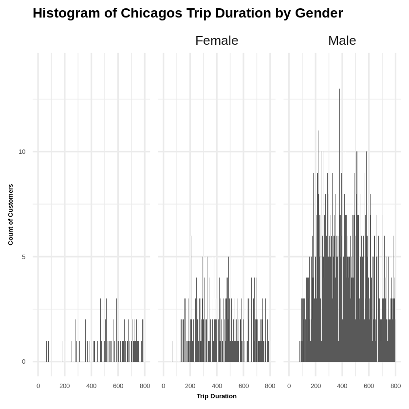

```r
ggplot(aes(x = Trip.Duration), data = subset(chi, !is.na(Gender))) +
    geom_histogram(binwidth = 1) +
    scale_x_continuous(limits = c(0,800), breaks = seq(0,800,200)) +
    facet_wrap(~Gender)+
    xlab('Trip Duration')+
    ylab('Count of Customers')+
    ggtitle('Histogram of Chicagos Trip Duration by Gender')+
  theme(axis.text=element_text(size=8),
        axis.title=element_text(size=8),
       title=element_text(size=14,face="bold"))
```

**Yes, there is a difference. The most timeframe by male customers in the range of 200-600. Based on the provided data there is a significant higher concentration in terms of customers by male gender with the highest concentration about 400. As there are less data for female it is difficult to say if it such significant as it looks like but females seems to have a longer trip duration as the male in chicago.**

### Question 2

**How is the trip duration by start station Lincoln Memorial?**

```r
by(wash$Start.Station, wash$X, summary)
```

[output not shown]

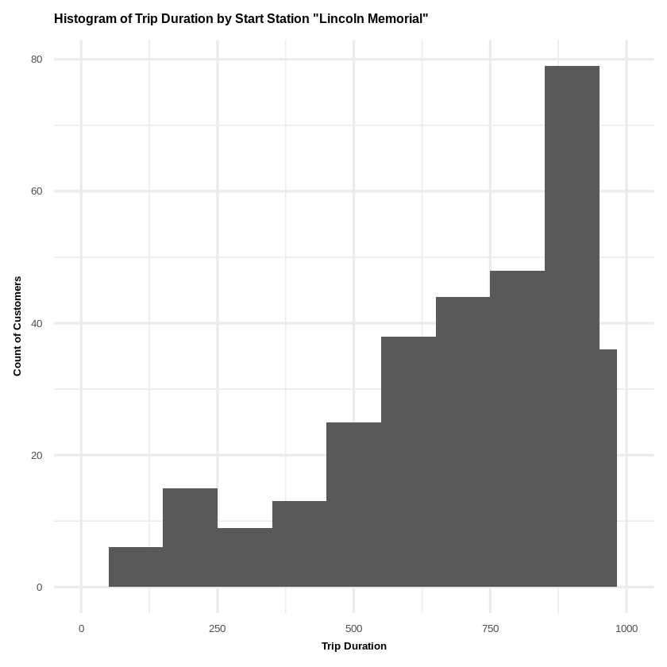

```r
qplot(x =Trip.Duration, data = subset(wash, Start.Station=='Lincoln Memorial')) +
    geom_histogram(binwidth = 100) +
    ggtitle('Histogram of Trip Duration by Start Station "Lincoln Memorial"')+
    labs(x = 'Trip Duration')+
    labs(y = 'Count of Customers')+
     theme(axis.text=element_text(size=8),
        axis.title=element_text(size=8),
       title=element_text(size=8,face="bold"))+xlim(0,1000)
```

```r
summary(wash)
```

```
       X                         Start.Time                   End.Time
 Min.   :      7   2017-02-19 12:19:00:    6   2017-03-09 17:54:00:    7
 1st Qu.: 434587   2017-02-20 11:35:00:    6   2017-03-28 18:11:00:    7
 Median : 872858   2017-02-24 17:46:00:    6   2017-01-13 17:48:00:    6
 Mean   : 873881   2017-03-01 08:20:00:    6   2017-01-31 08:49:00:    6
 3rd Qu.:1313305   2017-03-02 08:39:00:    6   2017-02-13 18:09:00:    6
 Max.   :1751392   2017-03-09 17:31:00:    6   2017-02-20 11:38:00:    6
                   (Other)            :89015   (Other)            :89013
 Trip.Duration                                   Start.Station
 Min.   :    60.3   Columbus Circle / Union Station     : 1700
 1st Qu.:   410.9   Lincoln Memorial                    : 1546
 Median :   707.0   Jefferson Dr & 14th St SW           : 1488
 Mean   :  1234.0   Massachusetts Ave & Dupont Circle NW: 1219
 3rd Qu.:  1233.2   Jefferson Memorial                  : 1068
 Max.   :904591.4   15th & P St NW                      : 1040
 NA's   :1          (Other)                             :80990
                                                End.Station
 Columbus Circle / Union Station                      : 1767
 Jefferson Dr & 14th St SW                            : 1603
 Lincoln Memorial                                     : 1514
 Massachusetts Ave & Dupont Circle NW                 : 1344
 Smithsonian-National Mall / Jefferson Dr & 12th St SW: 1103
 15th & P St NW                                       : 1077
 (Other)                                              :80643
      User.Type
           :    1
 Customer  :23450
 Subscriber:65600
```

### Question 3

**Is there a significant difference of the age by Female and Male Customers in New York?**

```r
by(ny$Birth.Year, ny$Gender, summary)
```

[output not shown]

[output not shown]

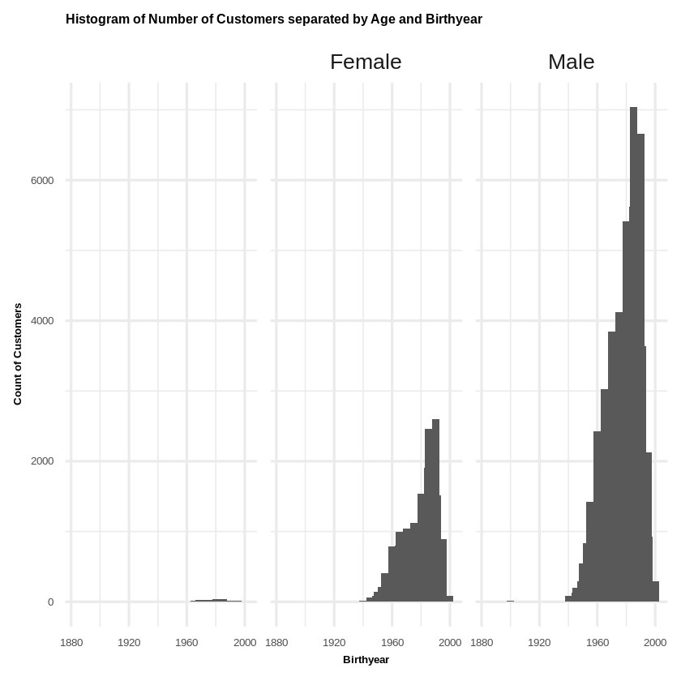

```r
qplot(x = Birth.Year, data = subset(ny, !is.na(Gender))) +
    geom_histogram(binwidth = 5) +
    facet_wrap(~Gender) +
    ggtitle('Histogram of Number of Customers separated by Age and Birthyear')+
    labs(x = 'Birthyear')+
    labs(y = 'Count of Customers')+
     theme(axis.text=element_text(size=8),
        axis.title=element_text(size=8),
       title=element_text(size=8,face="bold"))
```

```r
summary(ny)
```

[output not shown]

## Finishing Up

> Congratulations! You have reached the end of the Explore Bikeshare Data Project. You should be very proud of all you have accomplished!

> **Tip**: Once you are satisfied with your work here, check over your report to make sure that it is satisfies all the areas of the [rubric](https://review.udacity.com/#!/rubrics/2508/view).

## Directions to Submit

> Before you submit your project, you need to create a .html or .pdf version of this notebook in the workspace here. To do that, run the code cell below. If it worked correctly, you should get a return code of 0, and you should see the generated .html file in the workspace directory (click on the orange Jupyter icon in the upper left).

> Alternatively, you can download this report as .html via the **File** > **Download as** submenu, and then manually upload it into the workspace directory by clicking on the orange Jupyter icon in the upper left, then using the Upload button.

> Once you've done this, you can submit your project by clicking on the "Submit Project" button in the lower right here. This will create and submit a zip file with this .ipynb doc and the .html or .pdf version you created. Congratulations!

```r
# system('python -m nbconvert Explore_bikeshare_data.ipynb')
```